# Exploratory Data Analysis

### Mean Criminal Justice Score by Tier, Nonpunishment Policy, Prostitution Policy, and EU Membership

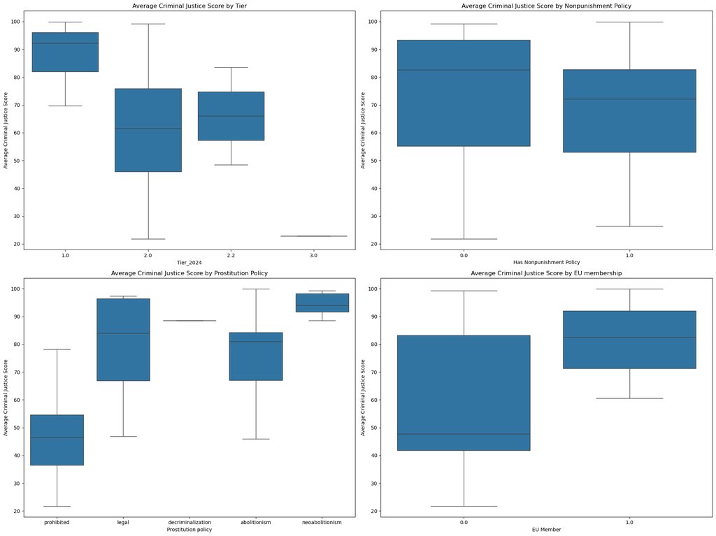

```python
def boxplots(df):
    # allow 4 subplots
    fig, ((ax1, ax2), (ax3, ax4)) = plt.subplots(2, 2, figsize=(20, 15))

    # 1. Mean Criminal Justice by Tier
    sns.boxplot(data=df, x='Tier_2024', y='Criminal_justice_mean', ax=ax1)
    ax1.set_title('Average Criminal Justice Score by Tier')
    ax1.set_ylabel('Average Criminal Justice Score')

    # 2. Mean Criminal Justice by Nonpunishment Policy
    sns.boxplot(data=df, x='Nonpunishment_policy_after2021', y='Criminal_justice_mean', ax=ax2)
    ax2.set_title('Average Criminal Justice Score by Nonpunishment Policy')
    ax2.set_xlabel('Has Nonpunishment Policy')
    ax2.set_ylabel('Average Criminal Justice Score')

    # 3. Mean Criminal Justice by Prostitution Policy
    sns.boxplot(data=df, x='prostitution_policy', y='Criminal_justice_mean', ax=ax3)
    ax3.set_title('Average Criminal Justice Score by Prostitution Policy')
    ax3.set_xlabel('Prostitution policy')
    ax3.set_ylabel('Average Criminal Justice Score')

    #4. Mean Criminal Justice by EU membership
    sns.boxplot(data=df, x='EU_members', y='Criminal_justice_mean', ax=ax4)
    ax4.set_title('Average Criminal Justice Score by EU membership')
    ax4.set_xlabel('EU Member')
    ax4.set_ylabel('Average Criminal Justice Score')


    plt.tight_layout()

correlation_matrix = boxplots(df)
```

The side-by-side visualization of these boxplots conveys that criminal justice scores are higher in Tier 1, countries with neoabolitionist prostitution policy, and EU members. The criminal justice score is alarmingly low for Tier 3 countries and interestingly lower in countries with prohibited prostitution. There is not a strong apparent difference for nonpunishment policy, but the visualization suggests that the mean criminal just scores among country that do not specify victim nonpunishment policy are actually slightly higher.

### Kruskal-Wallis test: Criminal justice scores by Tier

To take the boxplot results of the mean criminal justice scores by Tier one step further, the statistical significance of the difference between groups will be assessed by performing the Kruskal-Wallis test Kruskal-Wallis test along with Dunn’s pairwise analysis test. These nonparametric tests were chosen because they are more robust to violations of the assumptions of ANOVA– for example, the Kruskal-Wallis test can handle very small sample sizes and varying sample sizes across groups.

```python
import scikit_posthocs as sp
from scipy.stats import kruskal

# A condition for the KW test is that all groups must have at least two observations,
# so the data must be filtered to only include these.
df_filtered = df.groupby('Tier_2024').filter(lambda x: len(x) >= 2).copy()

# drop missing values
df_filtered = df_filtered.dropna(subset=['Criminal_justice_mean'])

# Perform Kruskal-Wallis test
groups = [df_filtered[df_filtered['Tier_2024'] == tier]['Criminal_justice_mean'] for tier in df_filtered['Tier_2024'].unique()]
h_stat, p_value = kruskal(*groups)
print(f"H-statistic: {h_stat}, P-value: {p_value}")

# Pairwise comparisons using Dunn’s test
pairwise_results = sp.posthoc_dunn(df_filtered, val_col='Criminal_justice_mean', group_col='Tier_2024', p_adjust='bonferroni')
print(pairwise_results)
```

```
H-statistic: 17.21799939487991, P-value: 0.0006374006592237717
          1.0       2.0  2.2       3.0
1.0  1.000000  0.000883  1.0  0.142186
2.0  0.000883  1.000000  1.0  1.000000
2.2  1.000000  1.000000  1.0  1.000000
3.0  0.142186  1.000000  1.0  1.000000
```

These results indicate that there is a statistically significant difference in the median of the mean criminal justice score between countries in Tier 1 and Tier 2 countries.